# Text Analysis

Topic Models

# Package Install

```r
install.packages(c("lsa", "NMF", "stm"))
```

# Topic Models

We already know that text is everywhere and our sentiment analysis was a reasonable crack at extracting some meaning from text. A common line of inquiry relates to what is expressed within the text. In traditionally social sciences, this was done through some form of content analysis – a coding scheme was developed by researchers, people read each comment and assigned it a code, some agreement statistics were computed, and any discrepencies were hashed out by the researchers. When this was the only option, it was servicable.

The amount information available to us now does not work for those traditional methods. Could you do this for thousands of tweets? With time, maybe. Could you do this with a few million articles? No. This is where topic models come to save the day. Our topic models are going to give us a pretty good idea about what texts are similar to other texts.

For the sake of exploration, it is great to know what topics are *latent* within a body of texts. It also has broader uses. When you search for something, topic models will return a set of documents that are likely to be related to that search.

## Latent Semantic Analysis

LSA is a building-block technique in the topic modeling field. It starts by building a *term-document matrix* (TDM). LSA, though, takes this TDM and replaces the raw counts with the tf-idf score. To this point, we are not doing anything that we already have not seen.

For our dive into LSA, we are going to rely on the `tm` package for our data prep. We will use it for its flexibility in data types – it can handle a corpus of .txt files in a directory, a single vector, or a data frame.

For clarity and immediate exploration, we will put them into a mutate line. We could easily do it tm_map(), but things become wonky as soon as we produce a corpus.

```r
library(dplyr)

library(stringr)

library(tm)

library(textstem)

if(Sys.info()["sysname"] == "Darwin") {
  load("~/courses/unstructured/data/allLyricsDF.RData")
} else load("C:/Users/sberry5/Documents/teaching/courses/unstructured/data/allLyricsDF.RData")

# load("D:/projects/courses/unstructured/data/allLyricsDF.RData")

# hardRemove = c(34, 78, 91, 94, 107, 136, 150, 202, 210, 213, 222, 229, 232,
#                239, 245, 248, 268, 276, 277, 284, 285, 291, 309, 310, 356,
#                403, 419, 424, 425, 460, 467, 482, 490, 497, 519, 532, 545,
#                555, 585, 586, 616, 639, 642, 648, 653, 654, 658, 682, 704,
#                705, 719, 722, 760, 780, 794, 795, 802, 832, 836, 851, 867,
#                872, 878, 891, 921, 924, 931, 944, 972, 985, 995, 1026, 1029,
#                1032, 1041, 1042, 1063, 1101, 1102, 1111, 1115, 1121, 1124,
#                1126, 1128, 1144, 1145, 1158, 1166, 1172, 1175, 1186, 1202,
#                1204, 1209, 1211, 1215, 1218, 1225, 1240, 1251, 1256, 1257,
#                1272, 1287, 1311, 1316, 1326, 1327, 1342, 1361, 1421, 1462,
#                1493, 1534, 1584, 1609, 1627, 1629, 1635, 1638, 1649, 1667,
#                1676, 1679, 1690, 1696, 1707, 1710, 1717, 1720, 1755, 1758,
#                1760, 1780, 1786, 1788, 1798, 1805, 1847, 1855, 1858, 1861,
#                1866, 1882, 1895, 1918, 1929, 1946, 1952, 1994, 2000, 2011,
#                2017, 2018, 2019, 2027, 2032, 2039, 2055, 2069, 2143, 2164,
#                2193, 2200, 2201, 2204, 2246, 2254, 2285, 2303, 2318, 2334,
#                2347, 2373, 2383, 2395, 2397, 2401, 2402, 2406, 2434, 2443,
#                2459, 2469, 2472, 2475, 2499, 2507, 2527, 2534, 2540, 2563,
#                2564, 2566, 2570, 2572, 2597, 2604, 2632, 2638, 2655, 2661,
#                2666, 2685, 2696, 2719, 2721, 2724, 2729, 2736, 2740, 2754,
#                2764, 2767, 2768, 2771, 2803, 2843, 2877, 2903, 2905, 2913,
#                2944, 2951, 2969, 2972, 2978, 2995, 3016, 3041, 3043, 3048, 3092)

cleanLyrics = allLyricsDF %>%
  filter(stringDistance < .1) %>%
  dplyr::select(lyrics, returnedArtistName, returnedSong) %>%
  mutate(text = as.character(lyrics),
         text = str_replace_all(text, "\n", " "),
         text = str_replace_all(text, "(\\[.*?\\])", ""),
         text = str_squish(text),
         text = gsub("([a-z])([A-Z])", "\\1 \\2", text),
         text = tolower(text),
         text = removeWords(text, c("’", stopwords(kind = "en"))),
         text = removePunctuation(text),
         text = removeNumbers(text),
         text = textstem::lemmatize_strings(text),
         doc_id = returnedSong,
         author = returnedArtistName) %>%
  select(doc_id, text, author) %>%
  as.data.frame()

lyricsCorpus = Corpus(DataframeSource(cleanLyrics))

lyricsCorpus[[1]][[2]]
```

```
  author       : character(0)
  datetimestamp: 2020-02-02 03:22:38
  description  : character(0)
  heading      : character(0)
  id           : ’Til I Can Make It On My Own
  language     : en
  origin       : character(0)
```

```r
meta(lyricsCorpus[1])
```

```
         author
1 Tammy Wynette
```

After creating our corpus, we can then pass our corpus into a term-document matrix:

```r
lyricsTDM = TermDocumentMatrix(lyricsCorpus, control = list(weighting =
                                                              function(x)
                                                                weightTfIdf(x, normalize =
                                                                              FALSE)))

inspect(lyricsTDM)
```

```
<<TermDocumentMatrix (terms: 7659, documents: 2235)>>
Non-/sparse entries: 131173/16986692
Sparsity           : 99%
Maximal term length: 32
Weighting          : term frequency - inverse document frequency (tf-idf)
Sample             :
        Docs
Terms    American Kids    Convoy Honky Tonk Badonkadonk
  aint        0.000000 14.141054              10.100753
  baby       11.543612  0.000000               0.000000
  get         1.484710 10.392968               8.165903
  gonna       0.000000 18.345353               0.000000
  good        0.000000  7.709342               1.927336
  like        1.014923  2.029847               3.044770
  little     16.839275  3.742061               0.000000
  love        0.000000  0.000000               1.512924
  wanna       0.000000  9.244995               9.244995
  want        0.000000  0.000000               0.000000
        Docs
Terms    International Harvester John Cougar, John Deere, John 3:16
  aint                  4.040301                          0.0000000
  baby                  0.000000                          0.0000000
  get                   2.969419                          0.0000000
  gonna                 0.000000                          0.0000000
  good                  1.927336                          0.0000000
  like                  2.029847                          0.0000000
  little                3.742061                          0.0000000
  love                  0.000000                          0.7564618
  wanna                 0.000000                          0.0000000
  want                  0.000000                          0.0000000
        Docs
Terms    One Piece at a Time She Got the Goldmine (I Got the Shaft)
  aint              0.000000                               4.040301
  baby              0.000000                               0.000000
  get               8.165903                              16.331806
  gonna             0.000000                              11.465846
  good              2.891003                              14.455017
  like              2.029847                               1.014923
  little            5.613092                               1.871031
  love              0.000000                               0.000000
  wanna             0.000000                               0.000000
  want              2.081665                               0.000000
        Docs
Terms    Shriner’s Convention Stuck Like Glue Teddy Bear
  aint               4.040301       0.0000000   0.000000
  baby               0.000000      17.3154176   0.000000
  get                3.711774       0.7423548   5.938839
  gonna              0.000000       0.0000000   4.586338
  good               5.782007       3.8546711   4.818339
  like               1.014923      23.3432393   1.014923
  little             1.871031       0.0000000  16.839275
  love               0.000000       0.7564618   0.000000
  wanna              0.000000       6.1633300   0.000000
  want               2.081665       2.0816650   4.163330
```

To illustrate tm’s flexibility, we could have done all of our cleaning in the control list.

The `lyricsTDM` object that we created can be easily explored like we would any other R object, so feel free to poke around in there.

If we just look at the information, though, we can see that we are dealing in very sparse space (99% sparse). This means that most words are not in most documents – sparsity is incredibly common in data. To solve the problem of sparsity, we need to perform some dimension reduction on our matrix (you will often here this referred to as *rank reduction*). Our dimension reduction, in this case, can work well because we are really trying to find words that belong to the same topic; for example, “car” and “truck” would reduce down to the same topic space.

### A Dive Into Linear Algebra

At the root of everything, we are going to be dealing with linear algebra (and optimization). Let’s play around with eigenvalues.

Let’s define a small matrix called *A*:

```r
Amatrix <- matrix(c(1, 3, 4, 5), nrow = 2, ncol = 2)

Amatrix
```

```
     [,1] [,2]
[1,]    1    4
[2,]    3    5
```

With that matrix, we might want to find two pieces of information: eigenvectors and eigenvalues.

An eigenvector is a special value that can perform a linear transformation to a matrix; an eigenvalue is the value that scales the eigenvector. You can conceptualize it by thinking that an eigenvector provides the direction to scale a matrix and the eigenvalue is the strength of the scale. We can find the eigenvalues and eigenvectors as follows:

$$Av = \lambda v$$
Where $v$ is the eigenvector and $\delta$ is the eigenvalue.

We can shuffle this equation around as follows:

$$Av - \lambda v = 0$$

As this is, we cannot factor this down any more. Remember that *A* is a matrix and $\delta$ is a single value, so we really can’t do much more. We can, however, make a substition with the identity matrix

$$Av - \lambda v = Av - \lambda I v$$

An identity matrix is the same size as the original matrix, with 1’s on the diagonal and 0’s elsewhere.

With that identity matrix in there, we can reduce this to:

$$(A - \lambda I)v = 0$$

To begin solving this more, we need to find the determinant (it finds the inverse of any matrix). The determinant for a 2x2 matrix is found as follows:

```r
matrix(c("a", "c", "b", "d"), nrow = 2, ncol = 2)
```

```
     [,1] [,2]
[1,] "a"  "b"
[2,] "c"  "d"
```

$$|A| = ad - bc$$

So in our aMatrix, we would have:

```r
1*5 - 4*3
```

```
[1] -7
```

```r
det(Amatrix)
```

```
[1] -7
```

To solve $(A - \lambda I)$, we get the following:

$$\begin{pmatrix}
1 & 4 \\
3 & 5
\end{pmatrix} - \lambda
\begin{pmatrix}
1 & 0 \\
0 & 1
\end{pmatrix}$$

Which goes to:

$$\begin{pmatrix}
1 & 4 \\
3 & 5
\end{pmatrix} -
\begin{pmatrix}
\lambda & 0 \\
0 & \lambda
\end{pmatrix}$$
And then:

$$\begin{pmatrix}
1 - \lambda & 4 \\
3 & 5 - \lambda
\end{pmatrix}$$

So to find the determinant of this matrix, we have:

$$det(A − \lambda I) = (1 − \lambda)(5 − \lambda) − (4 * 3)$$

And solving that equation will get us:

$$−7 − 6 \lambda + \lambda^2$$

To produce a quadratic equation:

$$\lambda^2 - 6 \lambda − 7$$

Which solves to -1 and 7: our eigenvalues!

All that, just to do the following:

```r
eigen(Amatrix)
```

```
eigen() decomposition
$values
[1]  7 -1

$vectors
           [,1]       [,2]
[1,] -0.5547002 -0.8944272
[2,] -0.8320503  0.4472136
```

How does this dimension reduction happen in LSA? It happens with singular value decomposition (SVD). The eigen decomposition that we just saw is a major component of SVD; SVD is but one of many forms of matrix factorization (we will see another soon) that will take a matrix (like the one we have) and break it down into 3 component matrices: $M=U*S*V$. The *S* is where SVD gets its name because it is a diagonal matrix of the singular values of *M* – these are scaling values. The *U* matrix is the matrix of the columns and the *V* matrix is the matrix of the rows. If we take the dot product (matrix multiplication) of these 3 matrices, we can get the original matrix back. While getting the original matrix back is good, we are want to reduce our dimensionality by specifying the number of topics that we select. When we decide upon a topic number, we are only keeping that number of columns within the *S* matrix. In effect, we are cutting out the lowest weights within the *S* matrix and the ensuing multiplication will provide a best fit matrix.

For a great run down of SVD (and the steps that come before), here is a great [demonstration](https://davetang.org/file/Singular_Value_Decomposition_Tutorial.pdf).

Here is another [SVD](https://web.mit.edu/be.400/www/SVD/Singular_Value_Decomposition.htm) by hand demonstration.

For a little more expanded understanding of LSA, here is a great [document](http://lsa.colorado.edu/papers/dp1.LSAintro.pdf).

Diving into SVD isn’t beyond us, we just need to keep moving along. It is definitely worth looking at a little more if you ever need to perform rank reduction on a matrix.

Any package that will do LSA will perform the SVD step for you, so you won’t need to do it manually – just know that it is being done!

Knowing the appropriate number of topics is impossible *a priori*, so we need to use various function to do that work for us. The lsa package has `dimcalc_share` (among others) that will work for finding the number of dimensions from our SVD.

**Warning!** This will take some time to run! Matrix multipliation on large matrices is always going to be computationally intensive!

```r
library(lsa)

lyricsRawMatrix = as.matrix(lyricsTDM)

s = svd(lyricsRawMatrix)$d # D is the diagonal matrix for our weights.

topicCount = dimcalc_share()(s)
```

```r
lyricsLSA = lsa(lyricsTDM, topicCount)

lyricsSpace = as.textmatrix(lyricsLSA)

lyricDistance = dist(t(lyricsSpace))
```

```r
associate(lyricsSpace, "drink")
```

```
   blurry
0.7147388
```

We can lower our threshold to get more terms:

```r
associate(lyricsSpace, "drink", threshold = .3)
```

```
     blurry       prick      dddday    heatwave    ticktock
  0.7147388   0.6059427   0.5285809   0.5285809   0.5285809
 haaaouuhhh        lois       ouhhh        ouuh       peaky
  0.4631740   0.4631740   0.4631740   0.4631740   0.4631740
      yeaaa    positive      cosmos     politic      payday
  0.4631740   0.4424262   0.4307571   0.4252686   0.3914618
    lightly       stool        peek gstewardess   inclusive
  0.3570020   0.3216507   0.3200677   0.3184808   0.3184808
       limo    seatback  stewardess    milehigh       pilot
  0.3184808   0.3184808   0.3184808   0.3184808   0.3184808
  stealings      fumble     airport   condition
  0.3153501   0.3144545   0.3031092   0.3017556
```

## Non-negative Matrix Factorization

Latent semantic analysis works and it is a great first step towards topic models; however, it is not really anything approaching state of the art. At this point there are other techniques that are far superior and one of those techniques is [non-negative matrix factorization](https://mlexplained.com/2017/12/28/a-practical-introduction-to-nmf-nonnegative-matrix-factorization/) (NNMF or NMF). Some of the basic set-up remains the same: we have a sparse matrix and we need to reduce the dimensionality of our matrix by somehow breaking the original matrix down into different components.

Since our data is already prepped, we can just pass our TDM right into the `nmf` function…in theory.

In reality, though, we need to add a small constant to our matrix. Why? The *k*-means that is being implemented on the backend of `nmf` will have some issues with all of those 0’s; in other words, it will handle a smaller sparse matrix, not a bigger sparse matrix. It is not big deal to add this small constant.

Here is an [in-depth treatment of nmf](https://www.cs.rochester.edu/u/jliu/CSC-576/NMF-tutorial.pdf).

```r
library(tibble)

lyricConvert = as.data.frame(as.matrix(lyricsTDM))

lyricsTibble = as_tibble(lyricConvert, .name_repair = "universal")

lyricsTibble = lyricsTibble %>%
  mutate_all(., funs(. + .1))

rownames(lyricsTibble) = rownames(lyricConvert)
```

**Warning!** This takes a really long time to run! The clustering that is happening within the matrices is a pain – if you have ever messed around with cluster selection, this run time will be familiar. Run it with smaller numbers of *k* to have it finish in decent time; the saved model object is in the data folder.

```r
library(NMF)

lyricsNNMF = nmf(lyricsTibble, 5, seed = 1001)

# save(lyricsNNMF, file = "D:/projects/courses/unstructured/data/nnmfOut.RData")

save(lyricsNNMF, file = "C:/Users/sberry5/Documents/teaching/courses/unstructured/data/nnmfOut.RData")
```

After waiting, we can finally start to see what words belong to what topics.

```r
if(Sys.info()["sysname"] == "Darwin") {
  load("~/courses/unstructured/data/nnmfOut.RData")
} else load("C:/Users/sberry5/Documents/teaching/courses/unstructured/data/nnmfOut.RData")



library(NMF)

wMatrix = as.data.frame(basis(lyricsNNMF))

head(wMatrix[order(-wMatrix$V1), ], 25)
```

```
               V1           V2           V3           V4           V5
man      5784.341 5.503788e+02 7.852292e+02 1.222525e+02 8.266113e+02
woman    3842.417 1.134386e+02 2.727432e+02 2.220446e-16 9.472454e+02
little   3750.091 6.274883e+01 1.029293e+03 7.514626e+03 2.220446e-16
year     3671.765 1.439073e+02 9.033265e+01 2.220446e-16 3.421770e+02
god      3574.394 4.303019e+02 8.714433e+01 2.220446e-16 3.349552e+02
old      3573.710 2.185553e+03 4.515678e+02 9.954004e+00 8.134830e+02
boy      3562.123 1.295069e+03 3.832780e+02 6.868669e+02 2.220446e-16
mama     3277.988 8.395707e+02 7.311217e+01 1.814701e+02 2.220446e-16
daddy    3187.106 1.967735e+02 4.085091e+01 2.434401e+01 7.069942e+01
work     3023.708 2.220446e-16 8.274562e+02 5.295138e+02 2.847757e+02
say      2927.611 4.804441e+01 7.218863e+02 8.896204e+02 3.196774e+03
life     2901.804 2.227693e+02 6.340345e+02 8.495743e+02 2.127386e+03
home     2799.490 1.102453e+03 9.730347e+02 6.479430e+02 7.946685e+02
live     2759.785 1.234392e+03 2.220446e-16 2.275571e+02 1.345727e+03
big      2753.996 1.122661e+03 5.387693e+02 6.722167e+02 4.493828e+01
kid      2681.611 1.893599e+02 2.566668e+02 6.995778e+01 5.096438e+01
good     2495.698 7.687114e+02 2.018839e+03 2.208341e+03 2.391288e+03
lot      2385.075 5.631401e+02 9.928289e+01 4.756747e+02 2.668821e+02
young    2325.332 3.270045e+02 1.942960e+02 2.288628e+01 3.064445e+02
bear     2283.998 3.703440e+02 7.050384e+02 2.220446e-16 3.597204e+01
lord     2275.903 1.113236e+03 6.576093e+02 2.220446e-16 4.499814e+02
american 2181.557 1.567097e+02 8.283307e+01 1.505453e+02 8.442313e-08
gimme    2168.875 3.598223e-01 4.134830e+01 6.462659e+01 7.862150e+01
money    2153.101 4.434642e+02 1.086488e+03 2.573048e+02 2.220446e-16
die      2141.846 3.762337e+02 6.271084e+01 2.220446e-16 5.618910e+02
```

```r
head(wMatrix[order(-wMatrix$V2), ], 25)
```

```
                  V1       V2           V3           V4           V5
country 1.455511e+02 6307.650 3.651297e+02 4.168187e+02 2.220446e-16
blue    1.897994e+02 5699.013 1.400255e+02 1.082251e+03 3.821156e+02
song    3.820203e-06 4774.467 2.062132e+01 2.075505e+03 1.353848e+02
roll    1.872300e+02 4583.657 4.031000e+02 1.325953e+03 2.220446e-16
sing    9.116930e+01 4442.962 2.220446e-16 9.075189e+02 9.186516e+01
rain    2.220446e-16 4328.922 1.025716e-12 1.935611e+02 7.175691e+02
play    4.906912e+01 4165.839 1.801023e+02 8.289593e+02 5.840699e+02
shine   2.741606e-15 3669.808 2.220446e-16 2.041379e+02 5.295659e+02
bye     2.220446e-16 3651.422 1.321793e+02 2.240209e-01 9.217053e+01
river   3.561589e+01 3532.821 1.790559e+02 2.169227e+01 1.562335e+02
cowboy  5.036144e+01 3430.777 3.573842e+02 4.703570e+01 7.782812e+01
sky     2.220446e-16 3165.033 1.951880e+02 4.260135e+02 2.424828e+02
wind    9.461673e+00 2931.944 7.610259e+02 5.490650e-06 6.591875e+02
moon    2.220446e-16 2819.595 5.562197e+02 8.343052e+02 3.968032e+02
ride    7.419245e+02 2805.900 1.176071e+02 1.560910e+03 2.220446e-16
sun     3.244061e+01 2722.304 9.053149e+02 1.192777e+03 2.682230e+02
music   2.908111e-11 2656.091 9.569888e+01 5.472705e+02 2.469291e+02
road    8.674228e+02 2643.011 1.858315e+03 1.284457e+03 2.538390e+01
texas   3.360441e+01 2607.884 1.112617e+02 2.220446e-16 1.694353e+02
honky   9.445767e+00 2583.913 5.473916e+01 2.218565e+01 1.361136e+02
star    2.987699e+02 2524.769 2.220446e-16 6.617644e+02 6.972274e+02
guitar  9.292121e+01 2498.276 9.021211e+01 2.338641e+02 1.282565e+02
blow    2.220446e-16 2471.501 3.439745e+01 6.853343e+02 4.776046e+02
fly     5.953567e+02 2465.057 2.220446e-16 2.445521e+02 4.150406e+02
train   1.541463e+02 2420.373 8.950925e+01 1.643883e+02 1.236147e+02
```

```r
head(wMatrix[order(-wMatrix$V3), ], 25)
```

```
                    V1           V2       V3           V4         V5
gonna     1.160159e+02 2.798314e+02 7856.598 4.021698e+03 1183.39097
honey     3.069541e+02 6.760043e-13 5115.729 2.470456e+02  212.25788
aint      1.826560e+03 2.141721e+02 4849.411 5.159064e+03  233.91665
goin      4.591708e+01 2.274998e+02 4614.864 5.038108e+00   96.76329
nothin    7.544520e+01 6.891046e+01 4599.976 5.458353e+01  108.30319
lovin     2.002254e-07 3.970114e+01 4534.953 8.150675e-15  203.33412
lookin    2.070353e+02 2.313551e+01 3704.758 6.325227e+01  195.29715
somebodys 5.932886e-13 9.279948e-05 3487.899 5.364073e+01  162.35458
trouble   3.270426e+02 5.748043e+01 3184.601 7.511618e-14  216.09159
comin     3.409711e+01 4.501635e+01 3062.707 8.196428e+01  121.41960
livin     1.468477e+02 8.278420e+01 3031.984 2.220446e-16  184.27259
thinkin   2.220446e-16 6.683049e-14 2861.643 3.400732e+02  174.63578
doin      4.321629e-01 6.944356e+01 2851.162 2.719922e+02  166.31427
back      1.884794e+03 1.296778e+03 2807.759 1.769688e+03 1454.72156
getcha    8.913757e-06 2.638317e+01 2724.145 6.290482e+01   99.21552
somethin  2.479570e-14 1.742644e+01 2723.016 3.410344e+02  179.45301
feelin    2.220446e-16 6.612291e+01 2701.401 2.181216e+02  206.12369
bout      1.961863e+02 4.791268e+01 2700.865 2.185178e+03   33.23346
huh       3.086820e+01 1.054351e+02 2493.310 7.894398e+01  109.61450
gettin    1.007296e+02 3.509797e+02 2487.409 4.431125e+01  187.64779
shake     3.854930e+02 4.081469e+01 2462.120 6.484702e+02  139.44973
runnin    1.796266e+02 8.927492e+01 2451.460 1.261843e+02  179.20753
fallin    2.220446e-16 1.124358e+02 2397.785 1.181688e+02  256.90090
keep      4.360365e+02 4.362284e+02 2355.732 8.181430e+02 2515.81205
tryin     2.220446e-16 6.217995e+01 2284.641 3.906524e+02  210.97446
```

```r
head(wMatrix[order(-wMatrix$V4), ], 25)
```

```
                  V1           V2           V3        V4           V5
wanna   2.220446e-16 3.872833e+01 4.435297e+02 10525.703 8.934038e+01
baby    2.220446e-16 7.969288e+00 1.851887e+03  8269.774 1.542649e+03
girl    1.498587e+03 5.206342e+02 5.089675e+02  7591.402 3.041815e+02
little  3.750091e+03 6.274883e+01 1.029293e+03  7514.626 2.220446e-16
yes     1.306466e+03 5.706170e+02 1.607807e+03  7217.444 2.268732e+02
drink   3.857323e+02 7.826676e+01 6.096143e+00  5776.340 1.145988e+02
kiss    8.435082e+01 2.220446e-16 2.220446e-16  5427.273 5.790064e+02
gotta   1.664839e-15 5.886528e+01 1.260936e+03  5182.002 1.584460e+02
aint    1.826560e+03 2.141721e+02 4.849411e+03  5159.064 2.339167e+02
get     1.951064e+03 7.302947e+02 2.133598e+03  4907.116 1.842025e+03
crazy   3.599038e+02 2.220446e-16 4.481741e-02  4366.934 8.349136e+02
want    1.677261e+02 6.172457e-07 3.827393e+00  4337.289 3.508411e+03
dance   2.408978e-05 1.616854e+03 2.220446e-16  4301.287 3.843096e+02
hey     9.983670e+02 4.007360e+02 9.784171e+02  4049.690 2.220446e-16
gonna   1.160159e+02 2.798314e+02 7.856598e+03  4021.698 1.183391e+03
like    1.308959e+03 1.439210e+03 1.531130e+03  3826.982 2.115863e+03
tonight 2.220446e-16 1.455783e+02 5.371073e+02  3808.743 1.921148e+03
night   2.602737e+02 1.530887e+03 1.160083e+03  3768.964 1.866963e+03
have    1.288761e+02 2.258050e+02 4.901442e+01  3767.185 7.962376e+02
bite    2.865600e+02 2.339450e+02 2.028931e+00  3437.190 1.012771e+02
ooh     1.710648e+02 1.072171e+02 7.877661e+01  3276.977 2.594333e+02
’       4.284582e+01 5.373070e+01 6.485505e+01  3265.351 7.011359e+01
you     2.220446e-16 3.153435e+02 1.620069e+03  3152.524 2.220446e-16
make    1.042898e+03 2.141810e+02 9.517890e+02  3034.077 2.958659e+03
rock    1.772478e+02 2.248038e+03 2.593367e+01  3011.448 2.220446e-16
```

```r
head(wMatrix[order(-wMatrix$V5), ], 25)
```

```
                V1           V2           V3         V4       V5
love     840.89637 4.320885e+02 1.959413e+02  743.76475 6367.330
heart     28.49453 1.821094e+02 8.615152e+02  276.67192 4835.323
never    792.76852 6.177066e+02 3.419841e+02  604.77235 4161.698
still    641.88406 5.734889e+02 5.461508e+01  124.55783 3994.529
know    1164.37024 1.861604e+02 2.825487e+02 1563.80935 3687.070
tell     859.61690 1.437191e+02 2.220446e-16  939.30085 3622.557
want     167.72611 6.172457e-07 3.827393e+00 4337.28888 3508.411
think   1122.20136 1.015459e+02 2.454736e-08 2019.69225 3500.612
will     985.92386 4.231119e+02 3.430084e-15  661.61304 3500.543
ever     385.45683 2.252248e+02 3.589715e+02  627.89092 3478.799
hold     125.06190 2.928770e+02 4.387016e-01  765.93421 3442.726
need     377.16544 1.691467e+02 2.142016e+03  853.40288 3389.893
feel      58.60599 6.509459e+02 4.584483e+02 2070.45797 3389.507
time    1364.53418 3.673715e+02 1.039106e+03 1093.41036 3381.265
one     2088.36578 2.604041e+02 3.260992e+02 1472.58700 3348.035
away     245.06873 1.057537e+03 2.220446e-16  451.33233 3308.333
can      757.44928 8.098299e+02 1.349327e+03 2205.97871 3294.917
mind      87.59759 4.322413e+02 4.825924e+02  739.97710 3214.139
say     2927.61135 4.804441e+01 7.218863e+02  889.62044 3196.774
lie      115.61135 1.183090e+02 4.353720e-13  514.57362 3170.830
now     1055.98483 1.530635e+02 9.113981e+02 1413.31445 3057.445
see     1290.60878 8.648968e+02 1.615040e+02 1108.37316 3021.255
someone   27.88213 1.969366e+01 9.706310e+01   25.22885 2992.459
give    1760.68817 3.085918e+01 6.106635e+02  246.93700 2983.705
lose     534.17139 7.757406e+01 9.206063e+01  650.83695 2978.132
```

We can find all of the words that fit within a topic (the *features*) based upon a pre-defined threshold.

```r
lyricFeatures = extractFeatures(lyricsNNMF)

rownames(wMatrix[lyricFeatures[[1]], ])
```

```
  [1] "gimme"        "daddy"        "year"         "wife"
  [5] "monday"       "american"     "dad"          "daddys"
  [9] "mom"          "thank"        "bitty"        "god"
 [13] "kid"          "hometown"     "momma"        "rose"
 [17] "dear"         "family"       "mama"         "school"
 [21] "blink"        "woman"        "father"       "arrival"
 [25] "birthday"     "soldier"      "cinderella"   "woahohohoh"
 [29] "simple"       "son"          "america"      "proud"
 [33] "build"        "class"        "alyssa"       "job"
 [37] "hero"         "small"        "domestic"     "mother"
 [41] "bear"         "tommy"        "husband"      "rudy"
 [45] "nighttime"    "young"        "war"          "believer"
 [49] "die"          "redneck"      "sunday"       "marry"
 [53] "womans"       "liar"         "fifteen"      "eighteen"
 [57] "man"          "yard"         "fifty"        "cost"
```

[output cut: 26 more lines]

## Latent Dirichlet Allocation

LSA is the godfather of topic models and non-negative matrix factorization is a useful tool that we will see again (it is great for working with images and has great extensions to factor analysis). For topic models, though, the current state of the art is some variation of latent dirichlet allocation (LDA).

Let’s start with a brief demonstration of a standard latent dirichlet allocation (LDA) for topic modeling. A main point to take here is that the main driver of LDA is the dirichlet distribution. You can think of the dirichlet distribution as a multivariate beta distribution (many possible categories, with probabilities of belonging to the category being between 0 and 1).

Suffice it to say, one can approach this in (at least) one of two ways. In one sense, LDA is a dimension reduction technique, much like the family of techniques that includes PCA, factor analysis, non-negative matrix factorization, etc. We will take a whole lot of terms, loosely defined, and boil them down to a few topics. In this sense, LDA is akin to discrete PCA. Another way to think about this is more from the perspective of factor analysis, where we are keenly interested in interpretation of the result, and want to know both what terms are associated with which topics, and what documents are more likely to present which topics. The following is the plate diagram and description for standard LDA from [Blei, Jordan, and Ng (2003)](http://www.jmlr.org/papers/volume3/blei03a/blei03a.pdf).

Look at the citation count on that paper!

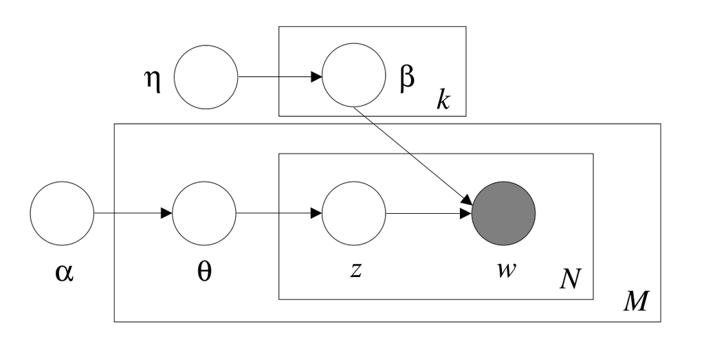

- $\alpha$ is the parameter of the Dirichlet prior on the per-document topic distributions
- $\eta$ is the parameter of the Dirichlet prior on the per-topic word distribution
- $\theta_m$ is the topic distribution for document *m*
- $\beta_k$ is the word distribution for topic *k*
- $z_{mn}$ is the topic for the n-th word in document *m*
- $w_{mn}$ is the specific word

Both *z* and *w* are from a multinomial draw based on the $\theta$ and $\beta$ distributions respectively. The key idea is that, to produce a given document, one draws a topic, and given the topic, words are drawn from it.

Here is Blei’s classic, short [introduction](http://www.cs.columbia.edu/~blei/papers/Blei2012.pdf) to probablistic topic models.

## Topic Probabilities

We will start by creating topic probabilities. There will be *k* = 3 topics. Half of our documents will have probabilities of topics for them ($\theta_1$) which will be notably different from the other half ($\theta_2$). Specifically, the first half will show higher probability of topic “A” and “B”, while the second half of documents show higher probability of topic “C”. What we’ll end up with here is an $m X k$ matrix of probabilities $\theta$ where each *m* document has a non-zero probability for each *k* topic. Note that in the plate diagram, these would come from a Dirichlet($\alpha$) draw rather than be fixed like we are doing, but hopefully this will make things clear starting out.

```r
library(tidyverse)

nDocs = 500                                       # Number of documents

wordsPerDoc = rpois(nDocs, 100)                   # Total words/terms in a document

thetaList = list(c(A = .60, B = .25, C = .15),    # Topic proportions for first and second half of data
                 c(A = .10, B = .10, C = .80))    # These values represent a Dir(alpha) draw

theta_1 = t(replicate(nDocs / 2, thetaList[[1]]))

theta_2 = t(replicate(nDocs / 2, thetaList[[2]]))

theta = rbind(theta_1, theta_2)
```

## Topic Assignments and Labels

With topic probabilities in hand, we’ll draw topic assignments from a categorical distribution.

```r
firsthalf = 1:(nDocs / 2)
secondhalf = (nDocs / 2 + 1):nDocs

Z = apply(theta, 1, rmultinom, n = 1, size = 1)   # draw topic assignment

rowMeans(Z[, firsthalf])                           # roughly equal to theta_1
```

```
[1] 0.58 0.26 0.16
```

Now, we can see which is the most likely topic.

```r
z = apply(Z, 2, which.max)
```

We have our list of documents and each document’s topic assignment.

## Topics

Next we need the topics themselves. Topics are probability distributions of terms, and in what follows we’ll use the Dirichlet distribution to provide the prior probabilities for the terms. With topic A, we’ll make the first ~40% of terms have a higher probability of occurring, the last ~40% go with topic C, and the middle more associated with topic B. To give a sense of the alpha settings, alpha = c(8, 1, 1) would result in topic probabilities of .8, .1, .1, as would alpha = c(80, 10, 10). We’ll use the gtools package for the rdirichlet function.

```r
nTerms = max(wordsPerDoc)

breaks = quantile(1:nTerms, c(.4,.6,1)) %>% round()

cuts = list(1:breaks[1], (breaks[1] + 1):breaks[2],
            (breaks[2] + 1):nTerms)

library(gtools)

B_k = matrix(0, ncol = 3, nrow = nTerms)

B_k[,1] = rdirichlet(n=1, alpha=c(rep(10, length(cuts[[1]])),    # topics for 1st 40% of terms
                                  rep(1,  length(cuts[[2]])),
                                  rep(1,  length(cuts[[3]]))))

B_k[,2] = rdirichlet(n=1, alpha=c(rep(1,  length(cuts[[1]])),    # topics for middle 20%
                                  rep(10, length(cuts[[2]])),
                                  rep(1,  length(cuts[[3]]))))

B_k[,3] = rdirichlet(n=1, alpha=c(rep(1,  length(cuts[[1]])),    # topics for last 40%
                                  rep(1,  length(cuts[[2]])),
                                  rep(10, length(cuts[[3]]))))
```

Here is a visualization of the term-topic matrix, where the dark represents terms that are notably less likely to be associated with a particular topic.

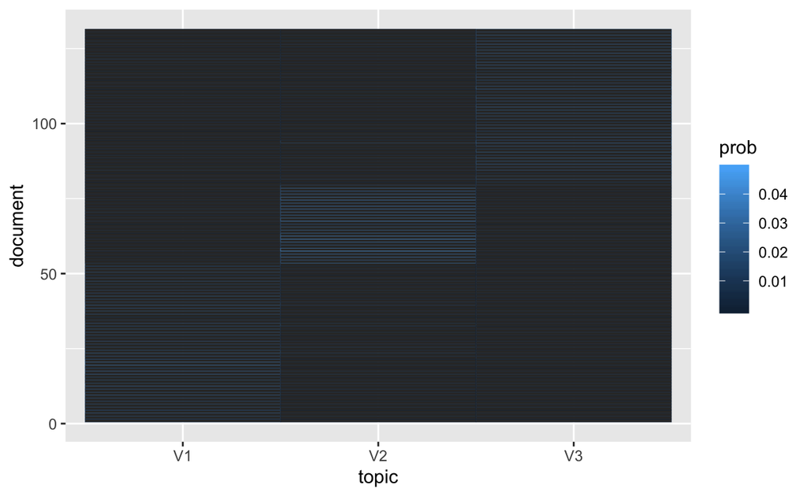

```r
library(ggplot2)

as.data.frame(B_k) %>%
  mutate(document = 1:nrow(.)) %>%
  tidyr::gather(key = topic, value = prob, -document) %>%
  ggplot(., aes(topic, document, color = prob)) +
  geom_tile()
```

Remember how we specified this – we assigned 40% to topic 1, 40% to topic 3, and left the middle 20% to topic 2. This visualization clearly shows this.

Now, given the topic assignment, we draw words for each document according to its size via a multinomial draw, and with that, we have our document-term matrix. However, we can also think of each document as merely a bag of words, where order, grammar etc. is ignored, but the frequency of term usage is retained.

```r
wordlist_1 = sapply(1:nDocs,
                    function(i) t(rmultinom(1, size = wordsPerDoc[i], prob = B_k[, z[i]])),
                    simplify = FALSE)

# smash to doc-term matrix
dtm_1 = do.call(rbind, wordlist_1)

colnames(dtm_1) = paste0('word', 1:nTerms)

# bag of words representation
wordlist_1 = lapply(wordlist_1, function(wds) rep(paste0('word', 1:length(wds)), wds))
```

If you print out the wordlist_1 object, you will see the words asssociated with each document.

## Topic Models

Now with some theory under our belt, we can take a look at analyzing real data.

Just like our sentiment analysis, there is a fair chunk of cleaning to do. The `textProcessor` function would do a lot of work for us, but we don’t really need it to do as much since we already created a pretty clean object. We are, however, going to randomly remove some observations from our data (if the reasons are not obvious now, they will be soon).

We are going to be constructing what are called [structural topic models](https://cran.r-project.org/web/packages/stm/vignettes/stmVignette.pdf).

```r
library(stm)

set.seed(1001)

holdoutRows = sample(1:nrow(cleanLyrics), 100, replace = FALSE)

lyricText = textProcessor(documents = cleanLyrics$text[-c(holdoutRows)],
                          metadata = cleanLyrics[-c(holdoutRows), ],
                          stem = FALSE)
```

```
Building corpus...
Converting to Lower Case...
Removing punctuation...
Removing stopwords...
Removing numbers...
Creating Output...
```

```r
lyricPrep = prepDocuments(documents = lyricText$documents,
                               vocab = lyricText$vocab,
                               meta = lyricText$meta)
```

```
Removing 3542 of 7483 terms (3542 of 124809 tokens) due to frequency
Your corpus now has 2135 documents, 3941 terms and 121267 tokens.
```

The stm package has some pretty nice facilities for determining a number of topics:

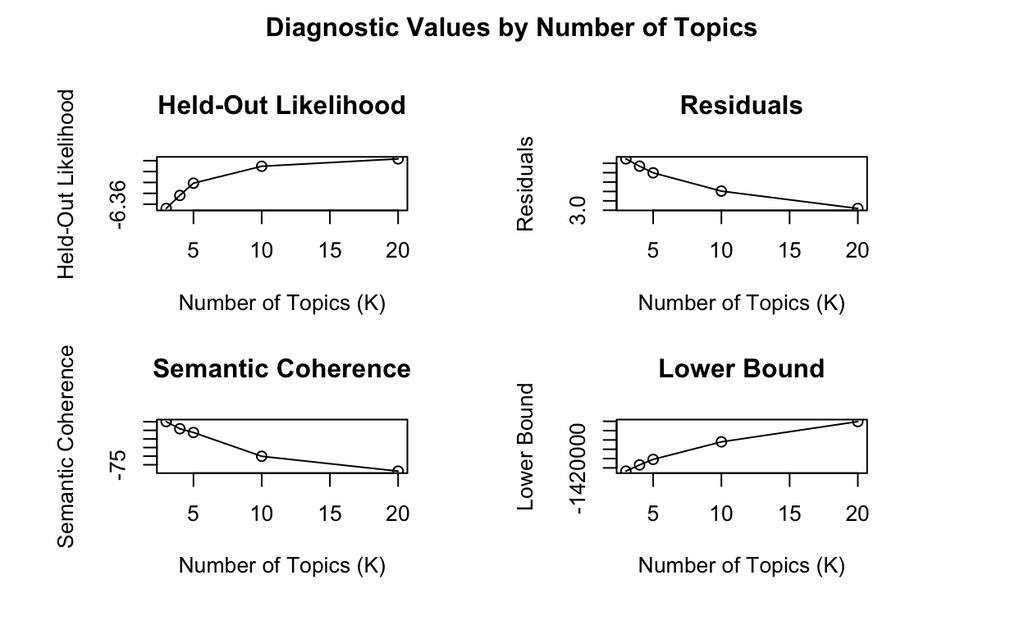

```r
kTest = searchK(documents = lyricPrep$documents,
             vocab = lyricPrep$vocab,
             K = c(3, 4, 5, 10, 20), verbose = FALSE)

plot(kTest)
```

The 4 plots that are returned are going to try to help us determine the best number of topics to take. I like to focus on semantic coherence (how well the words hang together – computed from taking a conditional probability score from frequent words) and the residuals. We want to have low residual and high semantic coherence. The residuals definitely take a sharp dive as we increase K. If we consider one of the major assumptions of LDA, we could almost always guess that we would need a great number of topics (i.e., if every topic that has ever existed, existed before writing, then we could have a huge numebr of topics). Our coherence seems to do pretty well with some of the lower numbers (not entirely surprising); coherence is essentially a measure of human interpretability. With all of these together, we can settle on 5 topics for our subsequent analyses. Just for your information, held-out likelihood can be characterized by how surprised the model would be with new words (it is often called perplexity). Lower bound relates to the lower bound of the marginal likelihood.

It is worthwhile to note that we can also do model selection with the stm package, but that is some work that will be best done if you want some additional playtime.

With our 5 topics, we can start our actual model:

```r
topics5 = stm(documents = lyricPrep$documents,
             vocab = lyricPrep$vocab, seed = 1001,
             K = 5, verbose = FALSE)
```

We can get a lot of output from our model, but we can focus on the expected topic proportions plot:

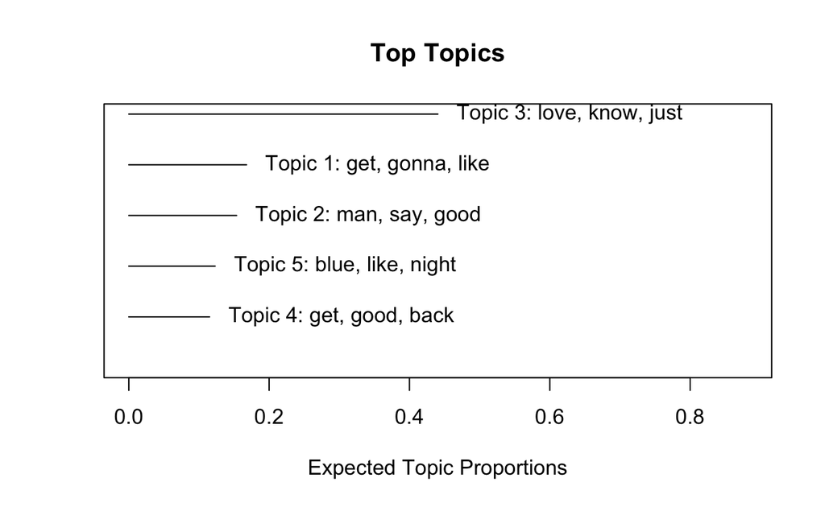

```r
plot(topics5)
```

We are essentially looking at the proportion of each topic, with a few of the highest probability words.

This is great, but it is really fun to see what emerges from the topics.

```r
labelTopics(topics5)
```

```
Topic 1 Top Words:
     Highest Prob: get, gonna, like, baby, yes, girl, wanna
     FREX: wanna, somebodys, lip, kiss, whoa, gimme, gonna
     Lift: jose, barstool, brad, comfortable, cuervo, favourite, forgettin
     Score: passionate, wanna, want, baby, getcha, gonna, tonight
Topic 2 Top Words:
     Highest Prob: man, say, good, get, little, just, aint
     FREX: family, monday, dad, daddy, poor, blink, american
     Lift: bead, bettys, buffalo, hardware, nobel, weed, adjust
     Score: pitiful, man, daddy, woman, year, little, son
Topic 3 Top Words:
     Highest Prob: love, know, just, heart, say, time, never
     FREX: someone, love, fool, true, believe, heart, goodbye
     Lift: anew, cope, exception, independently, justify, loudly, merely
     Score: love, heart, someone, lonely, please, know, hurt
Topic 4 Top Words:
     Highest Prob: get, good, back, road, yes, country, come
     FREX: bye, redneck, homegrown, mercury, nana, country, road
     Lift: appreciate, asphalt, backin, bandit, bangor, banjo, benz
     Score: mercury, country, bye, road, crazy, truck, redneck
Topic 5 Top Words:
     Highest Prob: blue, like, night, song, play, sing, rain
     FREX: blue, sky, wing, sea, holy, texas, rain
     Lift: afloat, backroad, beale, bowery, castaway, cloudless, drippin
     Score: blue, song, sky, texas, rain, holy, sing
```

We can look at lyrics that have a high probability of being associated with each topic:

```r
findThoughts(topics5, texts = lyricPrep$meta$text, n = 1)
```

```
 Topic 1:
     use somebodys baby use somebodys girl use somebodys lady use somebodys world start actin like king mountain good hear one thing jack somebody want back somebody want yes somebody want back somebody really want uh huh somebody want back somebody want back yes somebody want back use somebodys bab…
 Topic 2:
     good lie head railroad track wait double e train run poor poor pitiful poor poor pitiful poor poor pitiful boy let lord mercy woe woe good meet man hollywood aint name name really work good just like jesse james yes really work good credit gender put change lord sorta like ware blender poor poo…
 Topic 3:
     time stand right wrong catch fall love faith joy give one thing make love never give give love every time think love work stay see never give make thing rough show really mean love somebody though sometimes may see thing eye eye always meet half way time let pack thing go love stay never give g…
 Topic 4:
     good money tell go downtown buy mercury two crazy mercury lord crazy bout mercury go buy mercury cruise road good girl love steal friend get lucky steal back hear mercury lord crazy bout mercury go buy mercury cruise road hey now mama look fine drive around mercury crazy mercury lord crazy bout…
 Topic 5:
     walk along whistle song barefoot fancy free big riverboat pass us head new orleans go disappear around bend roll mississippi make feel like child cool river breeze like peppermint leave taste take back chewin straw tear overall cane pole old straw hat muddy river just like long lose friend roll…
```

One of the great things about topic models is that they are probablistic, meaning that each document has a certain probability of belonging to a topic:

```r
head(topics5$theta, 15)
```

```
            [,1]       [,2]      [,3]        [,4]        [,5]
 [1,] 0.09191905 0.01413337 0.8704069 0.006430083 0.017110548
 [2,] 0.06099811 0.02106655 0.6351280 0.020691773 0.262115541
 [3,] 0.30054032 0.05565129 0.2906076 0.170556589 0.182644174
 [4,] 0.14278372 0.02344705 0.7669340 0.041797812 0.025037390
 [5,] 0.06316368 0.01590227 0.9035990 0.005053800 0.012281230
 [6,] 0.38198998 0.09112394 0.4718530 0.039563423 0.015469621
 [7,] 0.02816728 0.05901451 0.1262628 0.146748436 0.639806939
 [8,] 0.04730883 0.03938974 0.6541620 0.049469428 0.209670023
 [9,] 0.03065825 0.54793081 0.3125906 0.069347241 0.039473110
[10,] 0.01296040 0.01043668 0.9643875 0.002343141 0.009872274
[11,] 0.21373179 0.09066457 0.6780863 0.009797561 0.007719740
[12,] 0.05560091 0.11459150 0.5901416 0.208696016 0.030970008
[13,] 0.58026477 0.12471249 0.0456675 0.235017824 0.014337415
[14,] 0.03529289 0.05622002 0.8815752 0.010274789 0.016637113
[15,] 0.14489057 0.01593130 0.6094620 0.011000612 0.218715553
```

```r
lyricPrep$meta[1, ]
```

```
                        doc_id
1 ’Til I Can Make It On My Own
                                                                                                                                                                                                                                                                                                            …
1 need time get mind may sometimes bother try touch even ask much time time now lord know need friend till get use lose let keep use til can make get matter try will time know call chance tear will fall pride time time say oh will bright day til lean mean til can make surely someday look see morning…
         author
1 Tammy Wynette
```

```r
lyricPrep$meta[3, ]
```

```
                   doc_id
3 Til Summer Comes Around
                                                                                                                                                                                                                                                                                                            …
3 another long summer come go know always end way boardwalk quiet carnival ride empty break heart tonight close eye one time spin around hold tightly word come kiss mouth 4 july ever burn brightly go understand promise back wander round town til summer come around get job work old park pier every su…
       author
3 Keith Urban
```

We can also see what terms are in documents 1:

```r
lyricPrep$documents[[1]]
```

```
     [,1] [,2] [,3] [,4] [,5] [,6] [,7] [,8] [,9] [,10] [,11] [,12]
[1,]   90  130  267  377  417  485  496  560  883  1137  1189  1252
[2,]    1    1    1    1    1    1    5    1    1     1     1     1
     [,13] [,14] [,15] [,16] [,17] [,18] [,19] [,20] [,21] [,22]
[1,]  1362  1417  1454  1718  1851  1884  1928  1945  1997  2002
[2,]     2     4     1     1     2     4     1     2     1     1
     [,23] [,24] [,25] [,26] [,27] [,28] [,29] [,30] [,31] [,32]
[1,]  2009  2012  2056  2092  2095  2100  2112  2147  2196  2216
[2,]     2     2     4     1     1     1     1     1     1     1
     [,33] [,34] [,35] [,36] [,37] [,38] [,39] [,40] [,41] [,42]
[1,]  2253  2278  2310  2602  2899  2938  3154  3163  3345  3363
[2,]     3     1     1     1     1     1     1     1     1     1
     [,43] [,44] [,45] [,46] [,47] [,48] [,49] [,50] [,51]
[1,]  3433  3519  3520  3521  3562  3615  3705  3850  3878
[2,]     1     7     1     6     1     2     4     3     1
```

```r
lyricPrep$vocab[lyricPrep$documents[[1]][1, ]]
```

```
 [1] "another"   "ask"       "behind"    "bother"    "bright"
 [6] "call"      "can"       "chance"    "day"       "even"
[11] "fall"      "find"      "friend"    "get"       "gonna"
[16] "hurtin"    "keep"      "know"      "lean"      "let"
[21] "lonely"    "look"      "lord"      "lose"      "make"
[26] "matter"    "may"       "mean"      "memory"    "mind"
[31] "morning"   "much"      "need"      "night"     "now"
[36] "pride"     "say"       "see"       "someday"   "sometimes"
[41] "sun"       "surely"    "tear"      "til"       "till"
[46] "time"      "touch"     "try"       "use"       "will"
[51] "without"
```

And 3:

```r
lyricPrep$documents[[3]]
```

```
     [,1] [,2] [,3] [,4] [,5] [,6] [,7] [,8] [,9] [,10] [,11] [,12]
[1,]   72   90  122  166  170  275  345  356  403   453   518   650
[2,]    1    1    8    1    4    1    1    1    1     2     1     4
     [,13] [,14] [,15] [,16] [,17] [,18] [,19] [,20] [,21] [,22]
[1,]   689   761   823   883  1080  1116  1117  1141  1143  1151
[2,]    10     1     1     1     1     1     1     2     1     1
     [,23] [,24] [,25] [,26] [,27] [,28] [,29] [,30] [,31] [,32]
[1,]  1174  1234  1270  1271  1357  1406  1417  1427  1493  1544
[2,]     3     1     1     1     1     1     1     1     1     2
     [,33] [,34] [,35] [,36] [,37] [,38] [,39] [,40] [,41] [,42]
[1,]  1590  1644  1815  1838  1846  1870  1884  1913  1962  1999
[2,]     1     2     1     2     1     2     2     1     1     2
     [,43] [,44] [,45] [,46] [,47] [,48] [,49] [,50] [,51] [,52]
[1,]  2024  2095  2168  2178  2202  2208  2310  2343  2346  2423
[2,]     1     1     1     1     1     2     2     1     2     1
     [,53] [,54] [,55] [,56] [,57] [,58] [,59] [,60] [,61] [,62]
[1,]  2498  2616  2649  2777  2803  2834  3181  3205  3269  3293
[2,]     1     1     1     1     1     1     1     2     1     1
     [,63] [,64] [,65] [,66] [,67] [,68] [,69] [,70] [,71] [,72]
[1,]  3343  3376  3447  3518  3519  3520  3521  3547  3569  3572
[2,]     6     1     1     2     5     1     2     1     2     1
     [,73] [,74] [,75] [,76] [,77] [,78] [,79] [,80] [,81] [,82]
[1,]  3668  3763  3784  3820  3833  3857  3866  3894  3895  3923
[2,]     2     1     1     1     1     1     1     2     1     1
     [,83]
[1,]  3932
[2,]     1
```

```r
lyricPrep$vocab[lyricPrep$documents[[3]][1, ]]
```

```
 [1] "always"     "another"    "around"     "baby"       "back"
 [6] "belong"     "boardwalk"  "bolt"       "break"      "burn"
[11] "carnival"   "close"      "come"       "count"      "cry"
[16] "day"        "ear"        "empty"      "end"        "ever"
[21] "every"      "everything" "eye"        "ferris"     "five"
[26] "fix"        "freeze"     "gear"       "get"        "girl"
[31] "grease"     "hand"       "heart"      "hold"       "job"
[36] "july"       "just"       "kiss"       "know"       "laugh"
[41] "light"      "long"       "love"       "may"        "mmm"
[46] "moment"     "motion"     "mouth"      "now"        "old"
[51] "one"        "park"       "pier"       "promise"    "quiet"
[56] "ride"       "rock"       "round"      "sound"      "spin"
[61] "stick"      "straighten" "summer"     "swear"      "tell"
[66] "tightly"    "til"        "till"       "time"       "tonight"
[71] "town"       "track"      "understand" "wander"     "way"
[76] "wheel"      "whisper"    "wind"       "winter"     "word"
[81] "work"       "year"       "yes"
```

While the previous methods would certainly allow us to classify new document, they do work best for informational retrieval. There are times that we don’t want to train a new model (and go through the step of determining a topic number), but instread just want to apply our trained model on new data. Topic models, on the other hand, are great for predicting topic probabilities for unseen document.

```r
newLyricText = textProcessor(documents = cleanLyrics$text[holdoutRows],
                          metadata = cleanLyrics[holdoutRows, ],
                          stem = FALSE)
```

```
Building corpus...
Converting to Lower Case...
Removing punctuation...
Removing stopwords...
Removing numbers...
Creating Output...
```

```r
newLyricCorp = alignCorpus(new = newLyricText, old.vocab = topics5$vocab)
```

```
Your new corpus now has 100 documents, 1375 non-zero terms of 1589 total terms in the original set.
214 terms from the new data did not match.
This means the new data contained 34.9% of the old terms
and the old data contained 86.5% of the unique terms in the new data.
You have retained 11307 tokens of the 11670 tokens you started with (96.9%).
```

```r
newLyricsFitted = fitNewDocuments(model = topics5, documents = newLyricCorp$documents,
                newData = newLyricCorp$meta, origData = lyricPrep$meta)
```

```
....................................................................................................
```

This will return each documents theta values.

Topic models can be extended to include covariates, where we are examining how much each topic contributes to a document given some other data.

This is where some real explanatory power comes into play!

```r
cleanLyrics = allLyricsDF %>%
  filter(stringDistance < .1) %>%
  dplyr::select(lyrics, returnedArtistName, returnedSong, date) %>%
  mutate(text = as.character(lyrics),
         text = str_replace_all(text, "\n", " "),
         text = str_replace_all(text, "(\\[.*?\\])", ""),
         text = str_squish(text),
         text = gsub("([a-z])([A-Z])", "\\1 \\2", text),
         text = tolower(text),
         text = removeWords(text, c("’", stopwords(kind = "en"))),
         text = removePunctuation(text),
         text = removeNumbers(text),
         text = textstem::lemmatize_strings(text),
         year = lubridate::year(date))

predictorText <- textProcessor(documents = cleanLyrics$text,
                          metadata = cleanLyrics,
                          stem = FALSE)
```

```
Building corpus...
Converting to Lower Case...
Removing punctuation...
Removing stopwords...
Removing numbers...
Creating Output...
```

```r
lyricPrep = prepDocuments(documents = predictorText$documents,
                               vocab = predictorText$vocab,
                               meta = predictorText$meta)
```

```
Removing 3587 of 7614 terms (3587 of 130834 tokens) due to frequency
Your corpus now has 2235 documents, 4027 terms and 127247 tokens.
```

```r
topicPredictor = stm(documents = lyricPrep$documents,
             vocab = lyricPrep$vocab, prevalence = ~ year,
             data = lyricPrep$meta, K = 5, verbose = FALSE)

yearEffect = estimateEffect(1:5 ~ year, stmobj = topicPredictor,
               metadata = lyricPrep$meta)

summary(yearEffect, topics = c(1:5))
```

```
Call:
estimateEffect(formula = 1:5 ~ year, stmobj = topicPredictor,
    metadata = lyricPrep$meta)


Topic 1:

Coefficients:
              Estimate Std. Error t value Pr(>|t|)
(Intercept) -1.247e+01  8.254e-01  -15.11   <2e-16 ***
year         6.338e-03  4.142e-04   15.30   <2e-16 ***
---
Signif. codes:  0 '***' 0.001 '**' 0.01 '*' 0.05 '.' 0.1 ' ' 1


Topic 2:

Coefficients:
             Estimate Std. Error t value Pr(>|t|)
(Intercept) 9.942e-02  8.370e-01   0.119    0.905
year        2.376e-05  4.198e-04   0.057    0.955


Topic 3:

Coefficients:
              Estimate Std. Error t value Pr(>|t|)
(Intercept) -2.0060725  0.6899322  -2.908  0.00368 **
year         0.0010691  0.0003458   3.091  0.00202 **
---
Signif. codes:  0 '***' 0.001 '**' 0.01 '*' 0.05 '.' 0.1 ' ' 1


Topic 4:

Coefficients:
              Estimate Std. Error t value Pr(>|t|)
(Intercept) 19.1768008  1.0084244   19.02   <2e-16 ***
year        -0.0094038  0.0005053  -18.61   <2e-16 ***
---
Signif. codes:  0 '***' 0.001 '**' 0.01 '*' 0.05 '.' 0.1 ' ' 1


Topic 5:

Coefficients:
              Estimate Std. Error t value Pr(>|t|)
(Intercept) -3.7564540  0.7133823  -5.266 1.53e-07 ***
year         0.0019532  0.0003578   5.459 5.31e-08 ***
---
Signif. codes:  0 '***' 0.001 '**' 0.01 '*' 0.05 '.' 0.1 ' ' 1
```

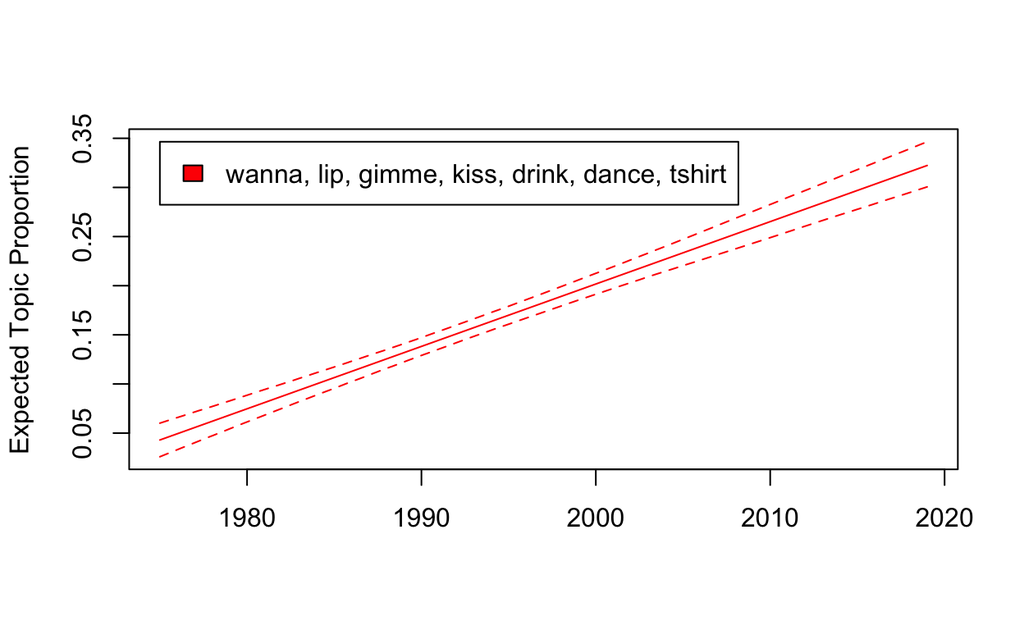

```r
plot.estimateEffect(yearEffect, "year", method = "continuous",
                    model = topicPredictor, topics = 1, labeltype = "frex")
```

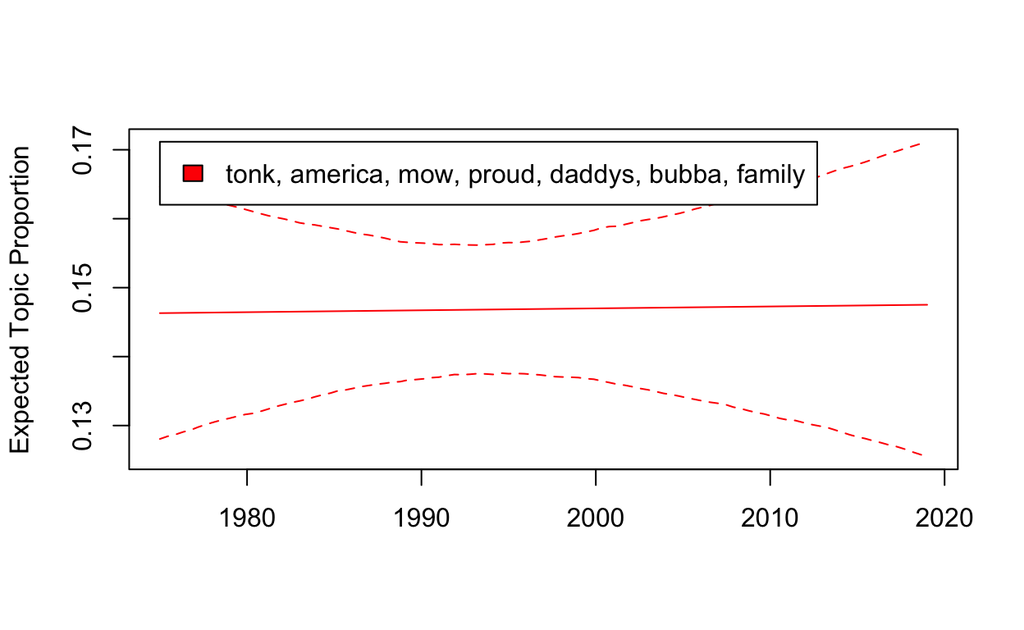

```r
plot.estimateEffect(yearEffect, "year", method = "continuous",
                    model = topicPredictor, topics = 2, labeltype = "frex")
```

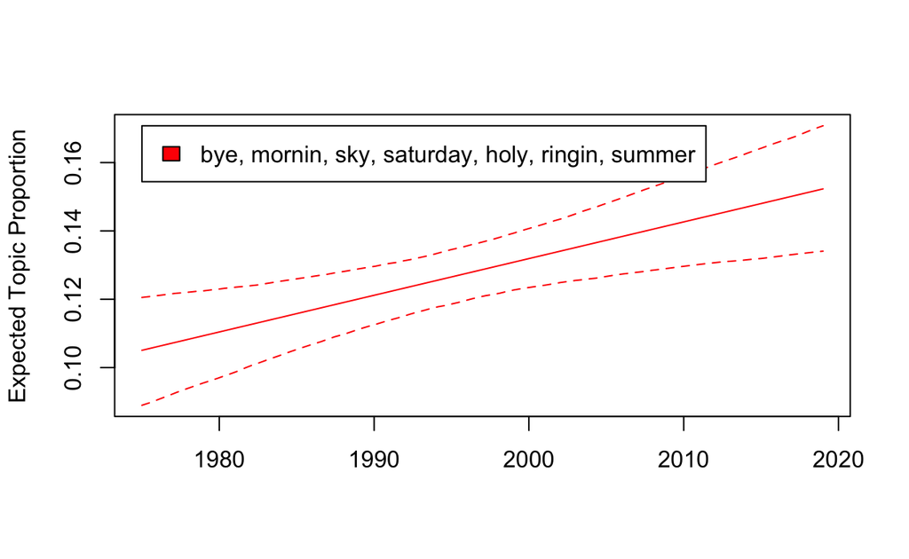

```r
plot.estimateEffect(yearEffect, "year", method = "continuous",
                    model = topicPredictor, topics = 3, labeltype = "frex")
```

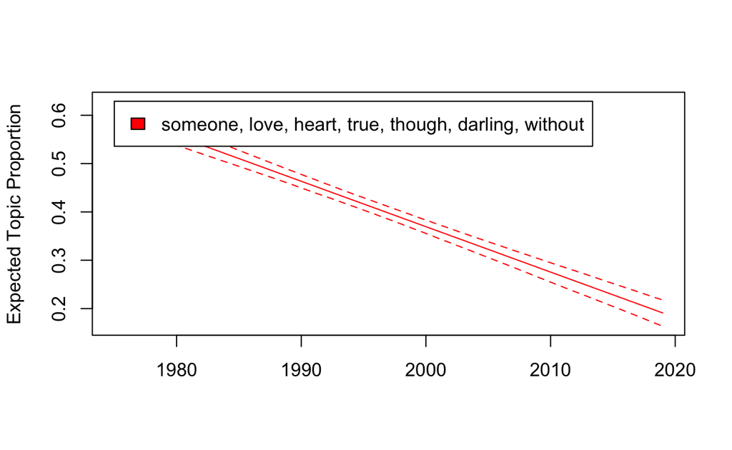

```r
plot.estimateEffect(yearEffect, "year", method = "continuous",
                    model = topicPredictor, topics = 4, labeltype = "frex")
```

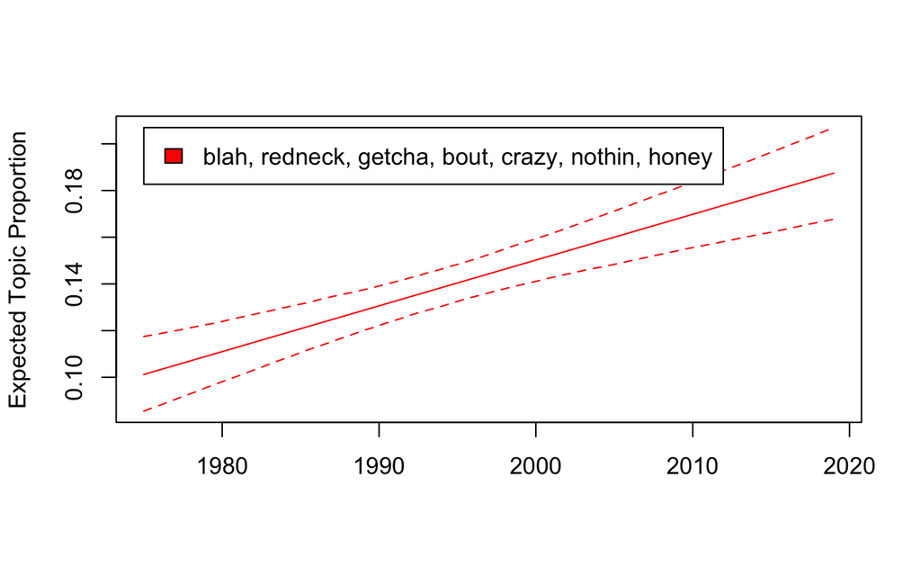

```r
plot.estimateEffect(yearEffect, "year", method = "continuous",
                    model = topicPredictor, topics = 5, labeltype = "frex")
```